# Introducción

## Objetivo del análisis

[figure not shown]

## Fuentes de datos

- ### [Misión de medición de las precipitaciones tropicales](https://en.wikipedia.org/wiki/Tropical_Rainfall_Measuring_Mission)

Nombre corto: TRMM_3B43  
Longname: TRMM (TMPA/3B43) Estimación de lluvia L3 1 mes 0.25 grado x 0.25 grado V7  
Cobertura espacial: -180.0, -50.0, 180.0, 50.0  
Cobertura temporal: 1998-01-01 hasta el presente  
Tamaño del archivo: 4.9 MB por archivo  
Resolución de datos  
Espaciales: 0.25 ° $\times$ 0.25 ° $\approx$ 110 $\times$ 111 km  
Temporal: 1 mes

Fuente: [NASA](https://disc.gsfc.nasa.gov/datasets/TRMM_3B43_V7/summary)

La **Misión de Medición de Lluvia Tropical (TRMM)** es una misión satelital conjunta de EE. UU. Y Japón para monitorear la precipitación tropical y subtropical y estimar su calentamiento latente asociado.

Los instrumentos de medición de la precipitación en el satélite TRMM incluyen el **Radar de precipitación (PR)**, un radar de exploración electrónica que opera a 13.8 GHz; **Imagen de microondas TRMM (TMI)**, un radiómetro de microondas pasivo **de nueve canales**; y **Escáner visible e infrarrojo (VIRS)**, un **radiómetro visible / infrarrojo de cinco canales**.

El propósito del **algoritmo 3B43** es producir la mejor estimación de la precipitación (en mm / h) y las estimaciones de error de precipitación de raíz cuadrada (RMS) de TRMM y otras fuentes de datos. El algoritmo combina múltiples estimaciones independientes de precipitación del TMI, Radiómetro de barrido avanzado para sistemas de observación de la Tierra (AMSR-E), Sensor especial de microondas (SSMI), Sensor especial de microondas y sonda (SSMIS), Unidad avanzada de sondeo de microondas (AMSU) , Sonda de Humedad de Microondas (MHS), geo-infrarrojo (IR) fusionado ajustado en microondas, y el análisis de pluviómetro Global Precipitation Climatology Center (GPCC) acumulado mensual. Todos los datos de microondas de entrada se intercalibran a las estimaciones de precipitación del Instrumento Combinado TRMM (TCI) (producto TRMM 3B31); las estimaciones de iIR se calculan usando la coincidencia de histograma de microondas-IR coincidente mensual; luego, los datos faltantes en campos individuales combinados de microondas de 3 horas se llenan con las estimaciones de IR. Después de completar el preprocesamiento, los campos multisatélite de 3 horas se suman para el mes y se combinan con el análisis de indicador mensual utilizando la ponderación de varianza inversa de error para formar la mejor estimación de la tasa de precipitación y estimaciones de error de precipitación RMS. Estas estimaciones cuadriculadas tienen una resolución temporal de mes calendario y una resolución espacial de 0.25 por 0.25 grados. La cobertura espacial se extiende desde 50 grados sur hasta 50 grados latitud norte.

Fuente: [NASA](https://mirador.gsfc.nasa.gov/collections/TRMM_3B43__007.shtml)

- ### [El Índice Oceánico de El Niño (ONI en inglés)](http://origin.cpc.ncep.noaa.gov/products/analysis_monitoring/ensostuff/ONI_v5.php)

El Índice Oceánico de El Niño (ONI) es un promedio de ejecución de 3 meses de [*ERSST.v5* (temperatura reconstruida extendida de la superficie del mar)](https://www.ncdc.noaa.gov/data-access/marineocean-data/extended-reconstructed-sea-surface-temperature-ersst-v5) anomalías de la temperatura de la superficie del mar (SST) en la **región Niño 3.4** (5° N-5° S, 120°-170° W)], basado en períodos de base centrados de 30 años actualizados cada 5 años. Los períodos cálido (rojo) y frío (azul) se definen con base en un umbral de +/- 0.5°C cuando el umbral de +/- 0.5°C se cumple durante un mínimo de 5 temporadas consecutivas superpuestas.

#### [Las regiones de El Niño](https://climatedataguide.ucar.edu/climate-data/nino-sst-indices-nino-12-3-34-4-oni-and-tni)

Los números de las regiones Niño 1,2,3 y 4 se corresponden con las etiquetas asignadas a las pistas de barco que cruzaron estas regiones.

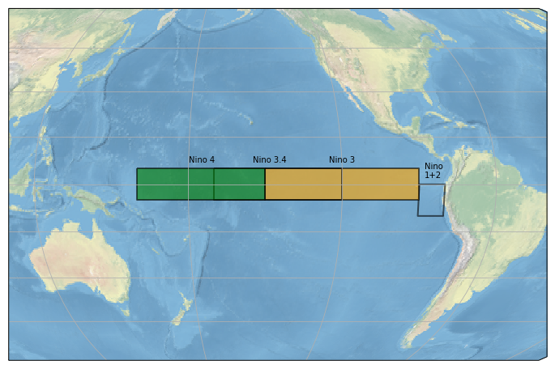

```python
%matplotlib inline
from src import helper_func as hf
hf.plot_nino_regions()
```

- **Niño 1 + 2 (0-10S, 90W-80W)** : La región Niño 1 + 2 es la más pequeña y la más oriental de las regiones SST del Niño, y corresponde con la región de la costa de Sudamérica donde El Niño era primero reconocido por las poblaciones locales.
- **Niño 3 (5N-5S, 150W-90W)**: esta región fue una vez el foco principal para monitorear y predecir El Niño.
- **Niño 3.4 (5N-5S, 170W-120W)**: Se puede pensar que las anomalías de El Niño 3.4 representan las TSM ecuatoriales promedio a lo largo del Pacífico desde aproximadamente la línea de la fecha hasta la costa de América del Sur.
- **Niño 4 (5N-5S, 160E-150W)**: El índice Niño 4 captura las anomalías de la TSM en el Pacífico ecuatorial central.

### Descarga de datos

- [ONI](http://origin.cpc.ncep.noaa.gov/products/analysis_monitoring/ensostuff/ONI_v5.php)
- [TRMM_3B43: TRMM (TMPA/3B43) Rainfall Estimate L3 1 month 0.25 degree x 0.25 degree V7](https://disc.gsfc.nasa.gov/datasets/TRMM_3B43_V7/summary)

## Deberes

> - Vaya a Internet y encuentre fuentes de datos alternativas para los datos de TRMM *Descubre la disponibilidad espacial y temporal* Descubre qué variables están disponibles
> - Vaya a Internet y busque publicaciones, que funcionan con conjuntos de datos en grillas de precipitaion.